# Contents

## Software

The software is a small python script that uses [ws4py](https://ws4py.readthedocs.org/en/latest/) as websocket library and [DMCC](https://github.com/Exadler/DMCC_Library) to interact with the motor controller cape.

### WS4PY

Excerpt from the [documentation of ws4py](https://ws4py.readthedocs.org/en/latest/sources/basics/):

ws4py provides a high-level, yet simple, interface to provide your application with WebSocket support. It is simple as:

```python
from ws4py.websocket import WebSocket
```

The `WebSocket <ws4py.websocket.WebSocket>` class should be sub-classed by your application. At the very least we suggest you override the `received_message(message) <ws4py.websocket.WebSocket.received_message>` method so that you can process incoming messages.

For instance a straight forward echo application would look like this:

```python
class EchoWebSocket(WebSocket):
    def received_message(self, message):
        self.send(message.data, message.is_binary)
```

Other useful methods to implement are:

- `opened() <ws4py.websocket.WebSocket.opened>` which is called whenever the WebSocket handshake is done.
- `closed(code, reason=None) <ws4py.websocket.WebSocket.closed>` which is called whenever the WebSocket connection is terminated.

You may want to know if the connection is currently usable or

`terminated <ws4py.websocket.WebSocket.terminated>`.

At that stage, the subclass is still not connected to any data source. The way ws4py is designed, you don't necessarily need a connected socket, in fact, you don't even need a socket at all.

```python
>>> from ws4py.messaging import TextMessage
>>> def data_source():
>>>     yield TextMessage(u'hello world')

>>> from mock import MagicMock
>>> source = MagicMock(side_effect=data_source)
>>> ws = EchoWebSocket(sock=source)
>>> ws.send(u'hello there')
```

### DMCC

The DMCC library enables python to interact with the motor controller cape. The cape generates a PWM proportional to a value between -10000 and 10000 which can be configured over a Python interface. The cape can be stacked 4 times.

For the Swank-Rats robot we use one cape to control two motors, one for left and one for right.

It provides an easy to use python interface.

```python
import DMCC

# turns on motor 1 on board 0 with 50% power
DMCC.setMotor(0, 1, 5000)

# reverse direction on motor two with 70% power
DMCC.setMotor(0, 2, -7000)

# turn off the motor
DMCC.setMotor(0,1,0)
```

### State machine

The state machine calculates the current speed of the motor left and right. Therefore the websocket library forwards the keys pressed and released to the current state, which is initialized with the state stop.

[figure not shown]

robot state machine

**Example:**

- The current state is `Stop`
- Press `left` the state `Stop` returns new state `L`
- Press `straight` the state `L` returns new state `FL`
- Release `left` the state `FL` return new state `F`

```python
class State:
    def __init__(self):
        pass

    def press(self, key):
        return Stop()

    def release(self, key):
        return Stop()

    def getLeft(self):
        return 0

    def getRight(self):
        return 0


class Stop(State):
    def press(self, key):
        if key == "left":
            return L()
        if key == "right":
            return R()
        if key == "straight":
            return F()
        if key == "backwards":
            return B()
        return Stop()

    def release(self, key):
        return Stop()


class F(State):
    def press(self, key):
        if key == "left":
            return FL()
        if key == "right":
            return FR()
        return Stop()

    def release(self, key):
        return Stop()

    def getLeft(self):
        return 100

    def getRight(self):
        return 100


class MessageParser:
    """Parses JSON messages an performs the according SwankRatsRobot action"""

    def __init__(self):
        self.robot = Robot()
        self.currentState = StateClasses.Stop()

    def execute(self, key, pressed):
        if pressed:
            self.currentState = self.currentState.press(key)
        else:
            self.currentState = self.currentState.release(key)

        self.robot.set(self.currentState.getLeft(), self.currentState.getRight())
```

## Supervisor

Supervisor is a client/server system that allows its users to control a number of processes on UNIX-like operating systems. It was inspired by the following:

- Convenience
- Accuracy
- Delegation
- Process Groups

Swank-Rats use it to automatic start and restart the robot script if it crashes. For this it is configured to try restart 100 times after crash or restart the system.

This file is a example config file which is used on the robots.

```
[program:swank-rats]
command=python /root/roboter-software/SwankRatsRoboterSoftware/Main.py
directory=/root/roboter-software/SwankRatsRoboterSoftware
autostart=true
autorestart=true
startretries=100
stderr_logfile=/var/log/swank-rats.err.log
stdout_logfile=/var/log/swank-rats.out.log
```

To enable web we added this to the config file of supervisor (more informations under the install section).

```
[inet_http_server]
port = 9001
username = admin
password = admin
```

After a restart the web ui can be located for example at `http://192.168.43.242:9001/`:

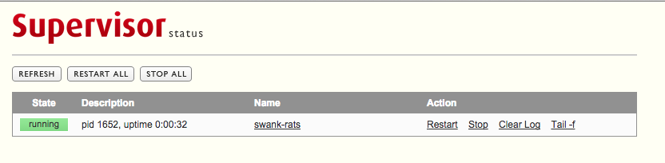

Supervisor web ui